# Final project

Youcef Djoudi

2023-11-29

[figure not shown]

Beat Map - image caption

## importing the Data

the data is crime statistcis for the city of Houston 2022. the dataset is posted by the City of Houston official website and here is the link (https://www.houstontx.gov/police/cs/Monthly_Crime_Data_by_Street_and_Police_Beat.htm)

```r
#install.packages("readxl")
library(readxl)
library(tidyverse)
library(dplyr)

file_path <- "NIBRSPublicViewDec22.xlsx"

crime_stats <- read_excel(file_path)
glimpse(crime_stats)
```

```
## Rows: 249,912
## Columns: 16
## $ Incident          <dbl> 10322, 10322, 11622, 15122, 15122, 16022, 16022, 180…
## $ RMSOccurrenceDate <dttm> 2022-01-01, 2022-01-01, 2022-01-01, 2022-01-01, 202…
## $ RMSOccurrenceHour <dbl> 0, 0, 0, 0, 0, 0, 0, 0, 0, 0, 0, 0, 0, 0, 0, 0, 0, 0…
## $ NIBRSClass        <chr> "90C", "520", "290", "290", "520", "520", "290", "22…
## $ NIBRSDescription  <chr> "Disorderly conduct", "Weapon law violations", "Dest…
## $ OffenseCount      <dbl> 1, 1, 1, 1, 1, 1, 1, 1, 1, 1, 1, 1, 1, 1, 1, 1, 1, 1…
## $ Beat              <chr> "3B10", "3B10", "8C20", "11H10", "11H10", "12D30", "…
## $ Premise           <chr> "Residence, Home (Includes Apartment)", "Residence, …
## $ StreetNo          <chr> "5500", "5500", "7100", "6540", "6540", "9031", "903…
## $ StreetName        <chr> "ANTOINE", "ANTOINE", "LEY", "AVENUE J", "AVENUE J",…
## $ StreetType        <chr> "DR", "DR", "RD", NA, NA, "DR", "DR", "ST", "LN", "S…
## $ Suffix            <chr> NA, NA, NA, NA, NA, NA, NA, NA, NA, NA, NA, NA, NA, …
## $ City              <chr> "HOUSTON", "HOUSTON", "HOUSTON", "HOUSTON", "HOUSTON…
## $ ZIPCode           <dbl> 77091, 77091, 77028, 77011, 77011, 77034, 77034, 770…
## $ MapLongitude      <dbl> -95.47323, -95.47323, -95.30201, -95.30826, -95.3082…
## $ MapLatitude       <dbl> 29.84436, 29.84436, 29.83137, 29.74446, 29.74446, 29…
```

##Data set the data set contains 16 variables and 249912 rows

##Crime stats by zipcode

```r
summary(crime_stats$ZIPCode)
```

```
##    Min. 1st Qu.  Median    Mean 3rd Qu.    Max.    NA's
##   36830   77022   77047   77060   77076   77876    3235
```

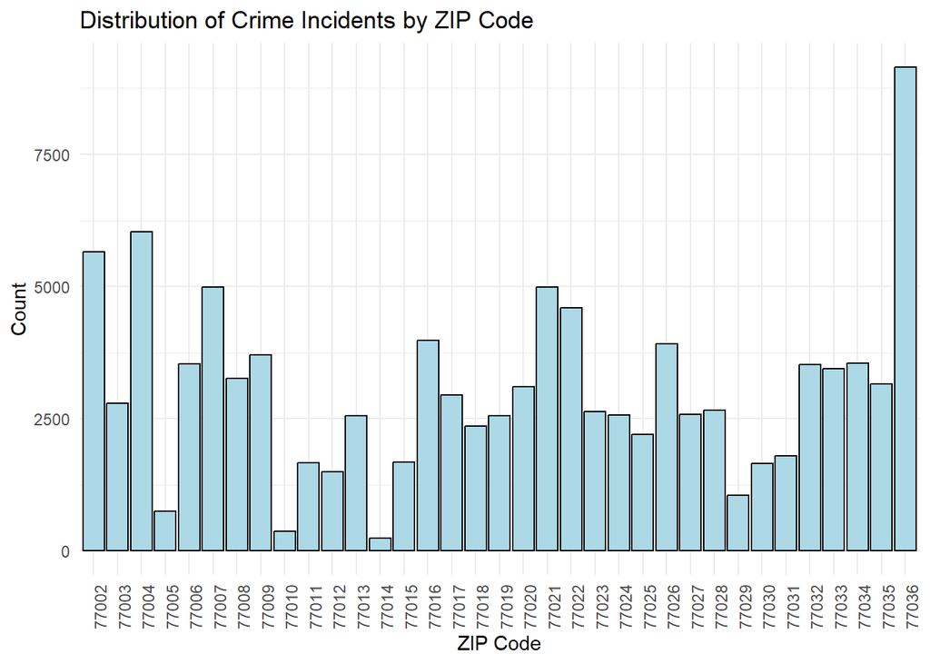

```r
library(ggplot2)

# Filter the data to include only ZIP codes between 77001 and 77036
filtered_data_1 <- crime_stats %>%
  filter(ZIPCode >= 77001, ZIPCode <= 77036)

# Create a count plot with rotated x-axis labels
ggplot(filtered_data_1, aes(x = as.factor(ZIPCode))) +
  geom_bar(fill = "lightblue", color = "black") +
  labs(
    title = "Distribution of Crime Incidents by ZIP Code",
    x = "ZIP Code",
    y = "Count"
  ) +
  theme_minimal() +
  theme(axis.text.x = element_text(angle = 90, hjust = 1))
```

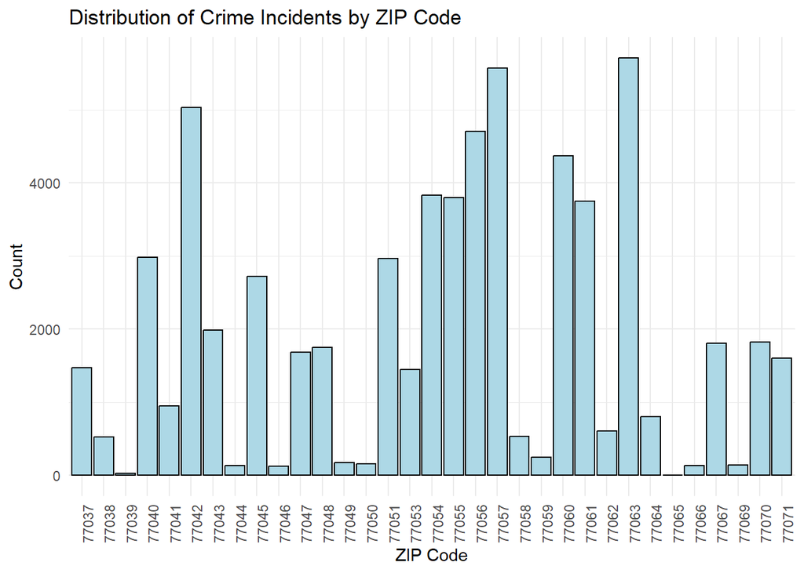

```r
# Filter the data to include only ZIP codes between 77037 and 77071
filtered_data_2 <- crime_stats %>%
  filter(ZIPCode >= 77037, ZIPCode <= 77071)

# Create a count plot with rotated x-axis labels
ggplot(filtered_data_2, aes(x = as.factor(ZIPCode))) +
  geom_bar(fill = "lightblue", color = "black") +
  labs(
    title = "Distribution of Crime Incidents by ZIP Code",
    x = "ZIP Code",
    y = "Count"
  ) +
  theme_minimal() +
  theme(axis.text.x = element_text(angle = 90, hjust = 1))
```

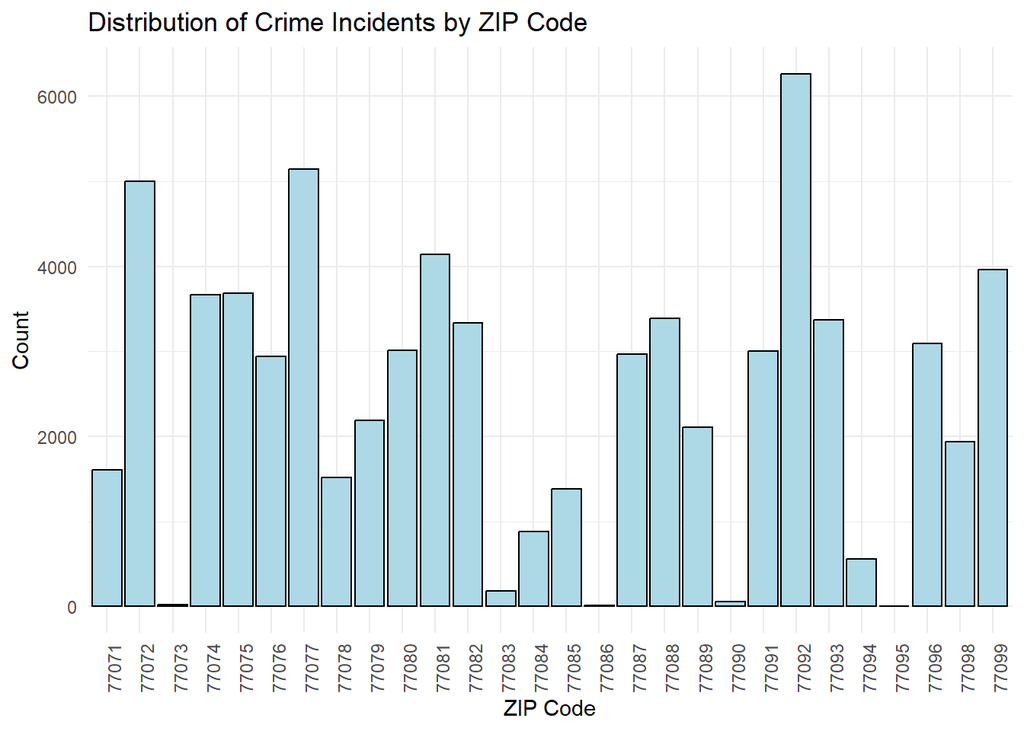

```r
# Filter the data to include only ZIP codes between 77071 and 77099
filtered_data_3 <- crime_stats %>%
  filter(ZIPCode >= 77071, ZIPCode <= 77099)

# Create a count plot with rotated x-axis labels
ggplot(filtered_data_3, aes(x = as.factor(ZIPCode))) +
  geom_bar(fill = "lightblue", color = "black") +
  labs(
    title = "Distribution of Crime Incidents by ZIP Code",
    x = "ZIP Code",
    y = "Count"
  ) +
  theme_minimal() +
  theme(axis.text.x = element_text(angle = 90, hjust = 1))
```

##Crime descriptions in the dataset

```r
unique_crime_descriptions <- unique(crime_stats$NIBRSDescription)
unique_crime_descriptions
```

```
##  [1] "Disorderly conduct"
##  [2] "Weapon law violations"
##  [3] "Destruction, damage, vandalism"
##  [4] "Burglary, Breaking and Entering"
##  [5] "Simple assault"
##  [6] "Driving under the influence"
##  [7] "Aggravated Assault"
##  [8] "All other offenses"
##  [9] "Trespass of real property"
## [10] "Robbery"
## [11] "Drunkenness"
## [12] "Theft from motor vehicle"
## [13] "Theft of motor vehicle parts or accessory"
## [14] "All other larceny"
## [15] "Intimidation"
```

[output cut: 46 more lines]

# Number of incidents per month

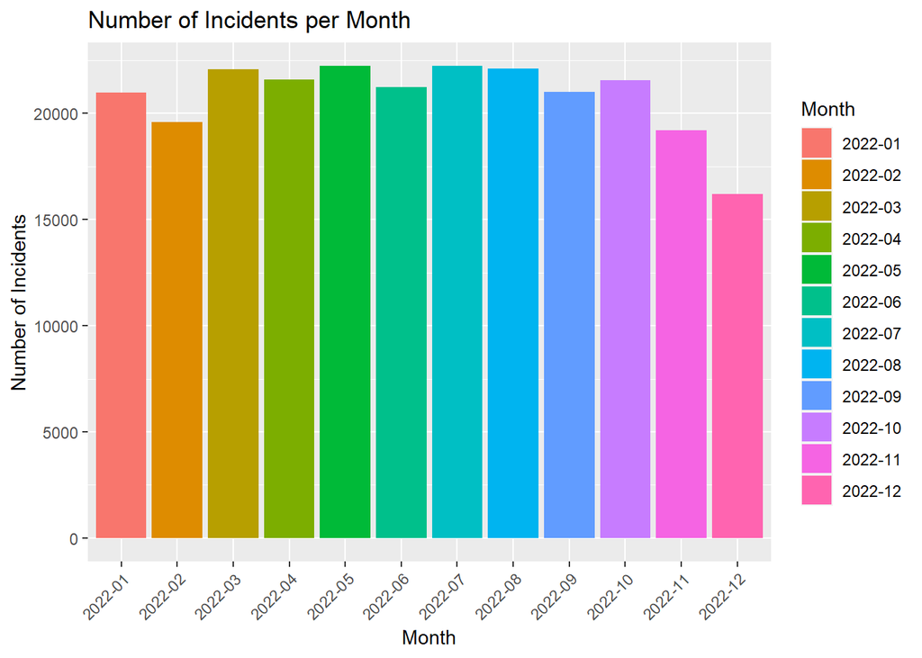

```r
# Convert 'RMSOccurrenceDate' to a date object
crime_stats$RMSOccurrenceDate <- as.Date(crime_stats$RMSOccurrenceDate)

# Extract month from 'RMSOccurrenceDate'
crime_stats$Month <- format(crime_stats$RMSOccurrenceDate, "%Y-%m")

# Create a bar graph for the number of incidents per month
ggplot(crime_stats, aes(x = Month, fill=Month)) +
  geom_bar() +
  labs(title = "Number of Incidents per Month",
       x = "Month",
       y = "Number of Incidents") +
  theme(axis.text.x = element_text(angle = 45, hjust = 1))
```

The most committed crimes in the city of Houston

```r
crime_counts <- crime_stats %>%
  group_by(NIBRSDescription) %>%
  summarise(Count = n()) %>%
  arrange(desc(Count))

crime_counts %>% head(10)
```

```
## # A tibble: 10 × 2
##    NIBRSDescription                          Count
##    <chr>                                     <int>
##  1 Theft from motor vehicle                  26165
##  2 Simple assault                            23173
##  3 Destruction, damage, vandalism            20620
##  4 Intimidation                              18682
##  5 All other larceny                         18045
##  6 Motor vehicle theft                       17123
##  7 Theft of motor vehicle parts or accessory 15771
##  8 All other offenses                        15063
##  9 Aggravated Assault                        14826
## 10 Burglary, Breaking and Entering           14063
```

The least crimes committed in the city of Houston

```r
crime_counts %>% tail(10)
```

```
## # A tibble: 10 × 2
##    NIBRSDescription                        Count
##    <chr>                                   <int>
##  1 Bad checks                                 16
##  2 Sexual assault with an object              10
##  3 Human Trafficking/Involuntary Servitude     7
##  4 Justifiable homicide                        7
##  5 Bribery                                     6
##  6 Peeping tom                                 5
##  7 Statutory rape                              5
##  8 Negligent manslaughter                      4
##  9 Promoting gambling                          3
## 10 Betting/wagering                            1
```

what if I want to see the most committed crimes by zip code

```r
crime_counts_by_zip <- crime_stats %>%
  group_by(NIBRSDescription, ZIPCode) %>%
  summarise(Count = n()) %>%
  arrange(ZIPCode, desc(Count)) %>%
  group_by(ZIPCode) %>%
  slice_head(n = 1)
crime_counts_by_zip
```

```
## # A tibble: 174 × 3
## # Groups:   ZIPCode [174]
##    NIBRSDescription          ZIPCode Count
##    <chr>                       <dbl> <int>
##  1 Drug, narcotic violations   36830     1
##  2 Drug, narcotic violations   46168     1
##  3 Theft from motor vehicle    77002   950
##  4 Theft from motor vehicle    77003   717
##  5 Theft from motor vehicle    77004   955
##  6 Theft from motor vehicle    77005   183
##  7 Theft from motor vehicle    77006   851
##  8 Theft from motor vehicle    77007  1066
##  9 Theft from motor vehicle    77008   693
## 10 All other larceny           77009   355
## # ℹ 164 more rows
```

What Beats have the highest incidents?

```r
beat_crime_counts <- crime_stats %>%
  group_by(Beat) %>%
  summarise(Count = n()) %>%
  arrange(desc(Count))

beat_crime_counts %>% head(10)
```

```
## # A tibble: 10 × 2
##    Beat  Count
##    <chr> <int>
##  1 12D10  5418
##  2 3B10   5273
##  3 15E40  5228
##  4 18F40  5075
##  5 22B20  5012
##  6 17E10  4973
##  7 19G10  4820
##  8 14D20  4779
##  9 18F20  4718
## 10 1A20   4593
```

What Beats have the lowest incidents?

```r
beat_crime_counts %>% tail(10)
```

```
## # A tibble: 10 × 2
##    Beat   Count
##    <chr>  <int>
##  1 7C50      22
##  2 6B50      17
##  3 21I20     13
##  4 23J40      8
##  5 21I70      4
##  6 HCC1       4
##  7 HCC5       4
##  8 HCC4       2
##  9 21I30      1
## 10 UH-3PD     1
```

Incidents per district

```r
# Extract district information from the 'Beat' variable
crime_stats <- crime_stats %>%
  mutate(District = substr(Beat, 1, 2))

# Group by district and count the number of incidents
incidents_by_district <- crime_stats %>%
  group_by(District) %>%
  summarise(IncidentCount = n()) %>%
  arrange(desc(IncidentCount))

# Print the resulting data
print(incidents_by_district)
```

```
## # A tibble: 28 × 2
##    District IncidentCount
##    <chr>            <int>
##  1 18               20901
##  2 20               19702
##  3 10               15591
##  4 1A               15553
##  5 17               13767
##  6 22               13473
##  7 14               12717
##  8 2A               12704
##  9 19               12494
## 10 3B               12327
## # ℹ 18 more rows
```

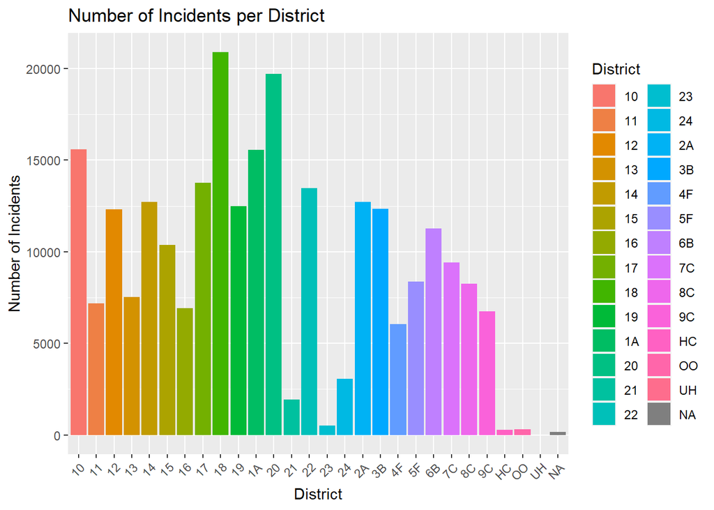

```r
# Create a bar graph for the number of incidents per district
ggplot(incidents_by_district, aes(x = District, y = IncidentCount, fill = District)) +
  geom_bar(stat = "identity") +
  labs(title = "Number of Incidents per District",
       x = "District",
       y = "Number of Incidents") +
  theme(axis.text.x = element_text(angle = 45, hjust = 1))
```

Districts with highest incidents and districts with the lowest incidents

```r
incidents_by_district %>% head(10)
```

```
## # A tibble: 10 × 2
##    District IncidentCount
##    <chr>            <int>
##  1 18               20901
##  2 20               19702
##  3 10               15591
##  4 1A               15553
##  5 17               13767
##  6 22               13473
##  7 14               12717
##  8 2A               12704
##  9 19               12494
## 10 3B               12327
```

```r
incidents_by_district %>% tail(10)
```

```
## # A tibble: 10 × 2
##    District IncidentCount
##    <chr>            <int>
##  1 16                6915
##  2 9C                6743
##  3 4F                6050
##  4 24                3071
##  5 21                1920
##  6 23                 521
##  7 OO                 299
##  8 HC                 274
##  9 <NA>               164
## 10 UH                   1
```

## How many murders were committed in the year 2022

```r
murder_data <- crime_stats %>%
  filter(NIBRSDescription =="Murder, non-negligent")
murder_data
```

```
## # A tibble: 411 × 18
##    Incident RMSOccurrenceDate RMSOccurrenceHour NIBRSClass NIBRSDescription
##       <dbl> <date>                        <dbl> <chr>      <chr>
##  1    83422 2022-01-01                        2 09A        Murder, non-negligent
##  2  1371522 2022-01-04                       10 09A        Murder, non-negligent
##  3  1852022 2022-01-05                       12 09A        Murder, non-negligent
##  4  1922122 2022-01-05                       14 09A        Murder, non-negligent
##  5  3070622 2022-01-08                        0 09A        Murder, non-negligent
##  6  3156622 2022-01-08                        7 09A        Murder, non-negligent
##  7  3162922 2022-01-08                        7 09A        Murder, non-negligent
##  8  3588822 2022-01-09                        4 09A        Murder, non-negligent
##  9  4288222 2022-01-10                       18 09A        Murder, non-negligent
## 10  4783322 2022-01-11                       21 09A        Murder, non-negligent
## # ℹ 401 more rows
## # ℹ 13 more variables: OffenseCount <dbl>, Beat <chr>, Premise <chr>,
## #   StreetNo <chr>, StreetName <chr>, StreetType <chr>, Suffix <chr>,
## #   City <chr>, ZIPCode <dbl>, MapLongitude <dbl>, MapLatitude <dbl>,
## #   Month <chr>, District <chr>
```

what zip code have the highest murder rate?

```r
highest_murder_count_zip <- murder_data %>%
  group_by(ZIPCode) %>%
  summarise(MurderCount = n()) %>%
  arrange(desc(MurderCount))

highest_murder_count_zip %>% head(10)
```

```
## # A tibble: 10 × 2
##    ZIPCode MurderCount
##      <dbl>       <int>
##  1   77036          21
##  2   77021          14
##  3   77004          13
##  4   77033          13
##  5   77087          11
##  6   77034          10
##  7   77042          10
##  8   77099          10
##  9   77009           9
## 10   77016           9
```

What zip code have the lowest murder rate?

```r
highest_murder_count_zip %>% tail(10)
```

```
## # A tibble: 10 × 2
##    ZIPCode MurderCount
##      <dbl>       <int>
##  1   77049           1
##  2   77091           1
##  3   77094           1
##  4   77098           1
##  5   77339           1
##  6   77345           1
##  7   77396           1
##  8   77489           1
##  9   77502           1
## 10   77598           1
```

murder rate per zip code

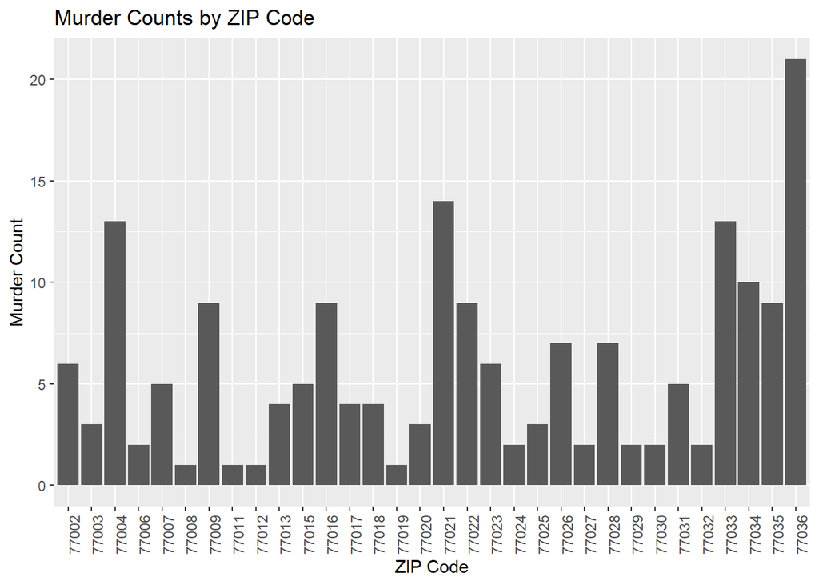

```r
filtered_data <- subset(murder_data, ZIPCode >= 77000 & ZIPCode <= 77036)

# Create a bar graph for murder counts by ZIPCode
ggplot(filtered_data, aes(x = as.factor(ZIPCode))) +
  geom_bar() +
  labs(title = "Murder Counts by ZIP Code",
       x = "ZIP Code",
       y = "Murder Count") +
  theme(axis.text.x = element_text(angle = 90, hjust = 1))
```

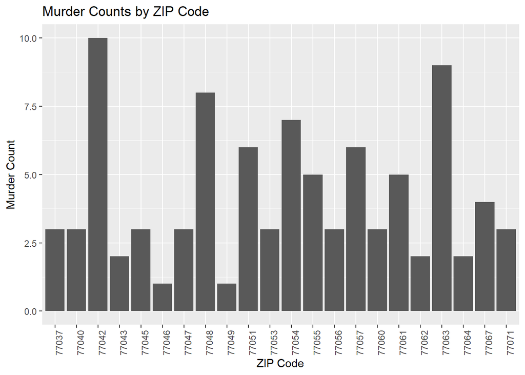

```r
filtered_data_1 <- subset(murder_data, ZIPCode >= 77037 & ZIPCode <= 77071)

# Create a bar graph for murder counts by ZIPCode
ggplot(filtered_data_1, aes(x = as.factor(ZIPCode))) +
  geom_bar() +
  labs(title = "Murder Counts by ZIP Code",
       x = "ZIP Code",
       y = "Murder Count") +
  theme(axis.text.x = element_text(angle = 90, hjust = 1))
```

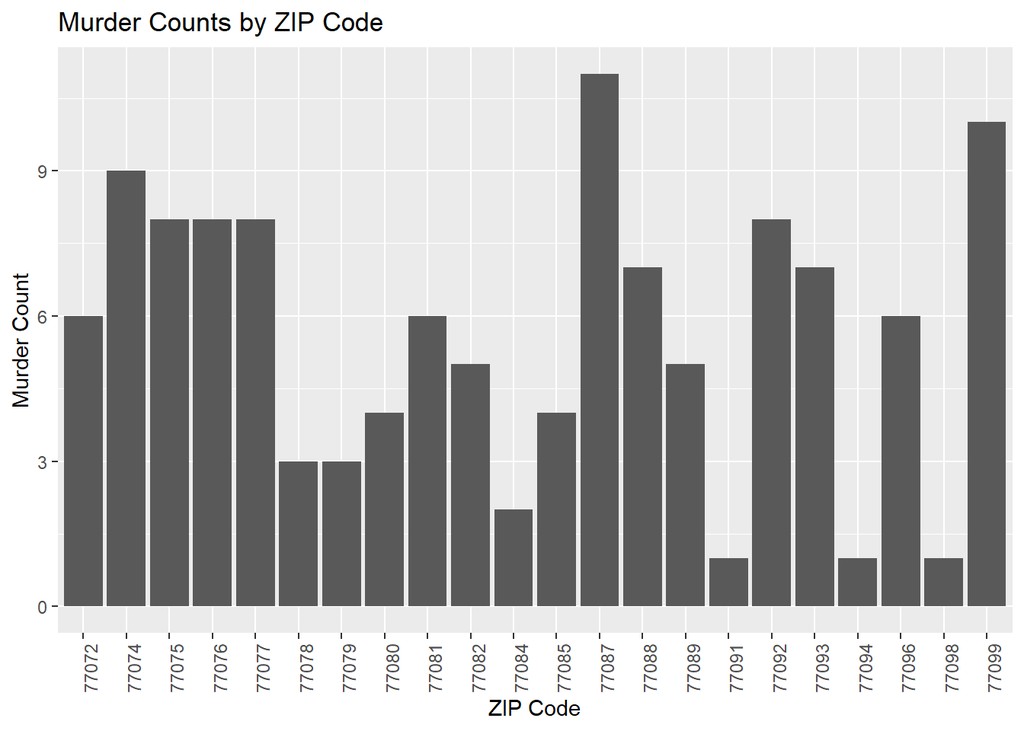

```r
filtered_data_2 <- subset(murder_data, ZIPCode >= 77072 & ZIPCode <= 77099)

# Create a bar graph for murder counts by ZIPCode
ggplot(filtered_data_2, aes(x = as.factor(ZIPCode))) +
  geom_bar() +
  labs(title = "Murder Counts by ZIP Code",
       x = "ZIP Code",
       y = "Murder Count") +
  theme(axis.text.x = element_text(angle = 90, hjust = 1))
```

Murder Distribution by month

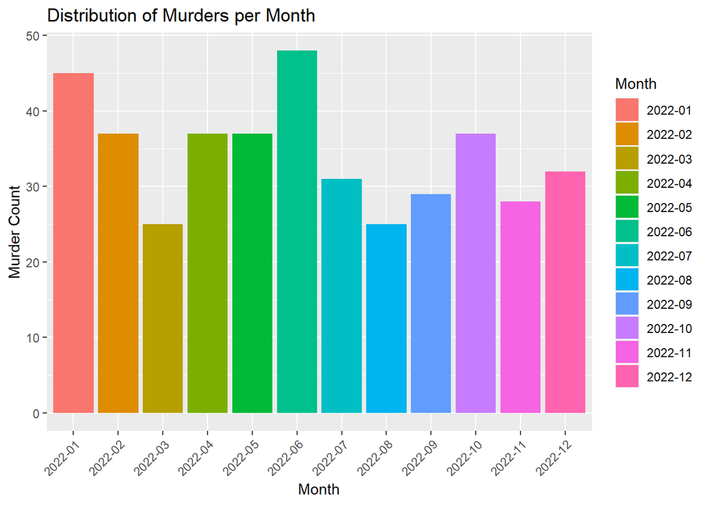

```r
# Convert 'RMSOccurrenceDate' to a date object
murder_data$RMSOccurrenceDate <- as.Date(murder_data$RMSOccurrenceDate)

# Extract month from 'RMSOccurrenceDate'
murder_data$Month <- format(murder_data$RMSOccurrenceDate, "%Y-%m")

# Create a bar graph for murder counts per month
ggplot(murder_data, aes(x = Month, fill=Month)) +
  geom_bar() +
  labs(title = "Distribution of Murders per Month",
       x = "Month",
       y = "Murder Count") +
  theme(axis.text.x = element_text(angle = 45, hjust = 1))
```

Murder rate per district

```r
# Create a subset for murder incidents
murder_data <- crime_stats %>% filter(NIBRSDescription == "Murder, non-negligent")

# Extract district information from the 'Beat' variable
murder_data <- murder_data %>%
  mutate(District = substr(Beat, 1, 2))

# Group by district and count the number of incidents
murder_by_district <- murder_data %>%
  group_by(District) %>%
  summarise(IncidentCount = n()) %>%
  arrange(desc(IncidentCount))

# Print the resulting data
print(murder_by_district)
```

```
## # A tibble: 23 × 2
##    District IncidentCount
##    <chr>            <int>
##  1 14                  41
##  2 17                  31
##  3 20                  30
##  4 19                  28
##  5 18                  27
##  6 10                  24
##  7 12                  21
##  8 13                  21
##  9 6B                  20
## 10 15                  18
## # ℹ 13 more rows
```

Plot Murder rate per district

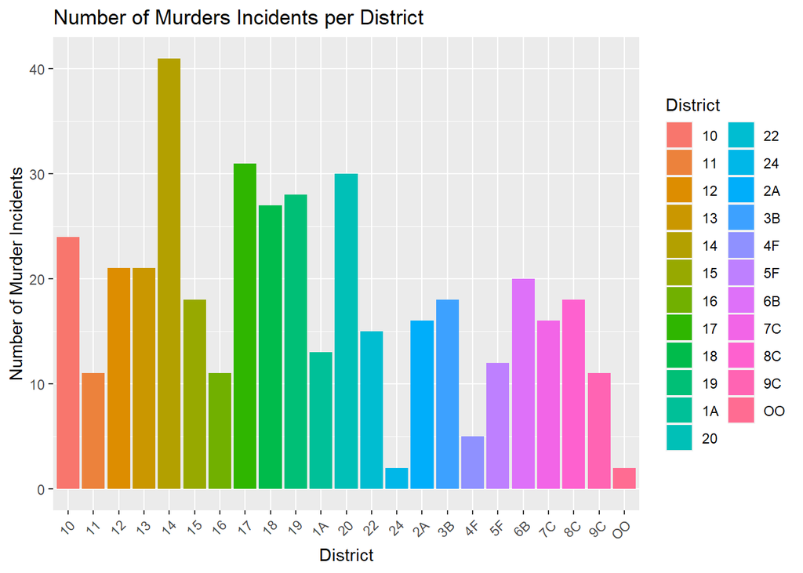

```r
ggplot(murder_by_district, aes(x = District, y = IncidentCount, fill = District)) +
  geom_bar(stat = "identity") +
  labs(title = "Number of Murders Incidents per District",
       x = "District",
       y = "Number of Murder Incidents") +
  theme(axis.text.x = element_text(angle = 45, hjust = 1))
```

How many robberies were committed?

```r
robbery_data<-crime_stats %>% filter(NIBRSDescription=="Robbery")
robbery_data
```

```
## # A tibble: 7,107 × 18
##    Incident RMSOccurrenceDate RMSOccurrenceHour NIBRSClass NIBRSDescription
##       <dbl> <date>                        <dbl> <chr>      <chr>
##  1    37722 2022-01-01                        0 120        Robbery
##  2    46822 2022-01-01                        0 120        Robbery
##  3    56222 2022-01-01                        1 120        Robbery
##  4   188022 2022-01-01                        1 120        Robbery
##  5  1052522 2022-01-01                        1 120        Robbery
##  6  9547622 2022-01-01                        1 120        Robbery
##  7   646322 2022-01-01                        2 120        Robbery
##  8   725222 2022-01-01                        2 120        Robbery
##  9  6937322 2022-01-01                        2 120        Robbery
## 10   783022 2022-01-01                        4 120        Robbery
## # ℹ 7,097 more rows
## # ℹ 13 more variables: OffenseCount <dbl>, Beat <chr>, Premise <chr>,
## #   StreetNo <chr>, StreetName <chr>, StreetType <chr>, Suffix <chr>,
## #   City <chr>, ZIPCode <dbl>, MapLongitude <dbl>, MapLatitude <dbl>,
## #   Month <chr>, District <chr>
```

Zip Code with highest robberies

```r
robbery_by_zip <- robbery_data %>%
  group_by(ZIPCode) %>%
  summarise(IncidentCount = n()) %>%
  arrange(desc(IncidentCount))
robbery_by_zip %>% head(10)
```

```
## # A tibble: 10 × 2
##    ZIPCode IncidentCount
##      <dbl>         <int>
##  1   77036           475
##  2   77057           221
##  3   77081           196
##  4   77072           184
##  5   77092           182
##  6   77063           180
##  7   77002           167
##  8   77004           165
##  9   77022           157
## 10   77074           155
```

Zip Code with the lowest robberies

```r
robbery_by_zip %>% tail(10)
```

```
## # A tibble: 10 × 2
##    ZIPCode IncidentCount
##      <dbl>         <int>
##  1   77336             2
##  2   77046             1
##  3   77069             1
##  4   77086             1
##  5   77208             1
##  6   77401             1
##  7   77494             1
##  8   77571             1
##  9   77584             1
## 10   77587             1
```

Robberies by Beat

```r
robbery_by_beat <- robbery_data %>%
  group_by(Beat) %>%
  summarise(IncidentCount = n()) %>%
  arrange(desc(IncidentCount))
robbery_by_beat
```

```
## # A tibble: 114 × 2
##    Beat  IncidentCount
##    <chr>         <int>
##  1 19G10           265
##  2 17E10           235
##  3 12D10           199
##  4 18F30           194
##  5 14D20           174
##  6 20G10           165
##  7 3B10            161
##  8 22B20           159
##  9 13D20           158
## 10 17E40           154
## # ℹ 104 more rows
```

Beats with the highest robberies

```r
robbery_by_beat %>% head(10)
```

```
## # A tibble: 10 × 2
##    Beat  IncidentCount
##    <chr>         <int>
##  1 19G10           265
##  2 17E10           235
##  3 12D10           199
##  4 18F30           194
##  5 14D20           174
##  6 20G10           165
##  7 3B10            161
##  8 22B20           159
##  9 13D20           158
## 10 17E40           154
```

Beats with lowest robberies

```r
robbery_by_beat %>% tail(10)
```

```
## # A tibble: 10 × 2
##    Beat   IncidentCount
##    <chr>          <int>
##  1 13D30              4
##  2 18F10              4
##  3 1A40               4
##  4 24C60              3
##  5 24C40              2
##  6 21I50              1
##  7 23J50              1
##  8 24C10              1
##  9 HCC1               1
## 10 UH-3PD             1
```

Robberies per month

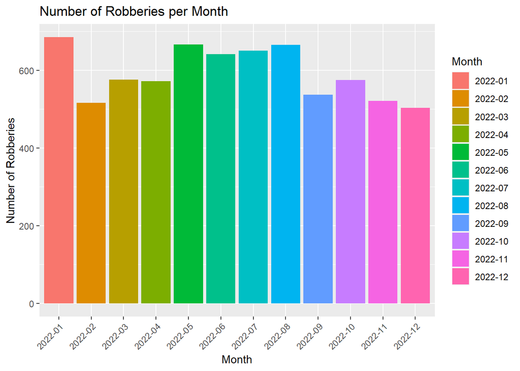

```r
# Convert 'RMSOccurrenceDate' to a date object
robbery_data$RMSOccurrenceDate <- as.Date(robbery_data$RMSOccurrenceDate)

# Extract month from 'RMSOccurrenceDate'
robbery_data$Month <- format(robbery_data$RMSOccurrenceDate, "%Y-%m")

# Create a bar graph for the number of robberies per month
ggplot(robbery_data, aes(x = Month, fill=Month)) +
  geom_bar() +
  labs(title = "Number of Robberies per Month",
       x = "Month",
       y = "Number of Robberies") +
  theme(axis.text.x = element_text(angle = 45, hjust = 1))
```

Robberies per district

```r
# Extract district information from the 'Beat' variable
robbery_data <- robbery_data %>%
  mutate(District = substr(Beat, 1, 2))

# Group by district and count the number of incidents
robbery_by_district <- robbery_data %>%
  group_by(District) %>%
  summarise(IncidentCount = n()) %>%
  arrange(desc(IncidentCount))

# Print the resulting data
print(robbery_by_district)
```

```
## # A tibble: 27 × 2
##    District IncidentCount
##    <chr>            <int>
##  1 18                 651
##  2 17                 562
##  3 19                 534
##  4 20                 527
##  5 14                 428
##  6 10                 423
##  7 6B                 378
##  8 3B                 372
##  9 22                 348
## 10 7C                 319
## # ℹ 17 more rows
```

Robberies by district

```r
robbery_by_district %>% head(10)
```

```
## # A tibble: 10 × 2
##    District IncidentCount
##    <chr>            <int>
##  1 18                 651
##  2 17                 562
##  3 19                 534
##  4 20                 527
##  5 14                 428
##  6 10                 423
##  7 6B                 378
##  8 3B                 372
##  9 22                 348
## 10 7C                 319
```

```r
robbery_by_district %>% tail(10)
```

```
## # A tibble: 10 × 2
##    District IncidentCount
##    <chr>            <int>
##  1 16                 209
##  2 8C                 197
##  3 9C                 184
##  4 4F                 108
##  5 24                  19
##  6 HC                   7
##  7 OO                   7
##  8 21                   1
##  9 23                   1
## 10 UH                   1
```

Plot robberies by district

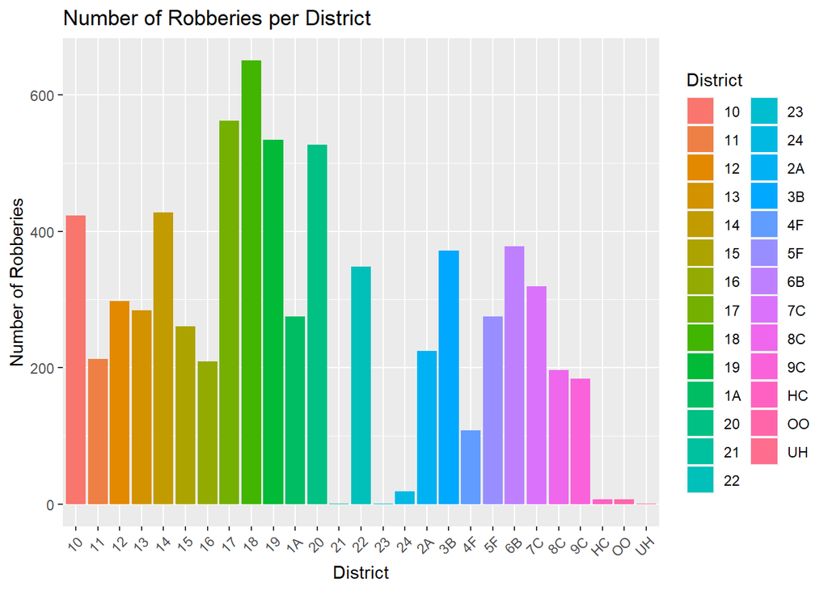

```r
ggplot(robbery_by_district, aes(x = District, y = IncidentCount, fill = District)) +
  geom_bar(stat = "identity") +
  labs(title = "Number of Robberies per District",
       x = "District",
       y = "Number of Robberies") +
  theme(axis.text.x = element_text(angle = 45, hjust = 1))
```

incidents by premise

```r
# Group by premise and count the number of incidents
incidents_by_premise <- crime_stats %>%
  group_by(Premise) %>%
  summarise(IncidentCount = n()) %>%
  arrange(desc(IncidentCount))

# Print the resulting data
print(incidents_by_premise)
```

```
## # A tibble: 45 × 2
##    Premise                              IncidentCount
##    <chr>                                        <int>
##  1 Residence, Home (Includes Apartment)         88454
##  2 Parking Lot, Garage                          49493
##  3 Highway, Road, Street, Alley                 37923
##  4 Other, Unknown                                9998
##  5 Convenience Store                             7202
##  6 Department, Discount Store                    6682
##  7 Commercial, Office Building                   6517
##  8 Restaurant                                    6025
##  9 Service, Gas Station                          5629
## 10 Hotel, Motel, ETC                             5356
## # ℹ 35 more rows
```

Crime incident per hour of the day

```r
# Group by the hour of the day and count the number of incidents
incidents_by_hour <- crime_stats %>%
  group_by(RMSOccurrenceHour) %>%
  summarise(IncidentCount = n()) %>%
  arrange(RMSOccurrenceHour)

# Print the resulting data
print(incidents_by_hour)
```

```
## # A tibble: 24 × 2
##    RMSOccurrenceHour IncidentCount
##                <dbl>         <int>
##  1                 0         12732
##  2                 1          9106
##  3                 2          8080
##  4                 3          6123
##  5                 4          4869
##  6                 5          4253
##  7                 6          4732
##  8                 7          6798
##  9                 8          9666
## 10                 9          8573
## # ℹ 14 more rows
```

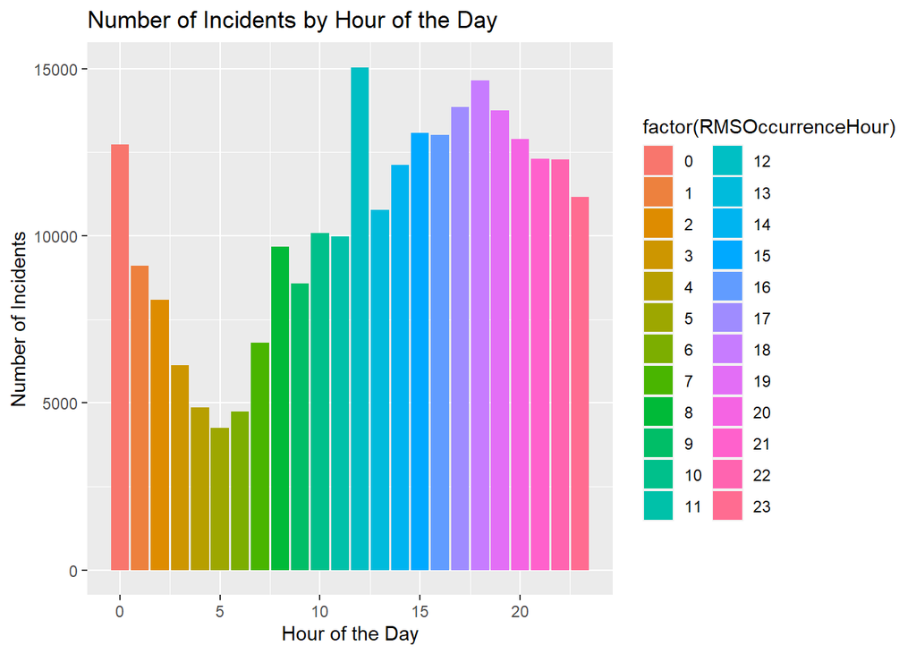

```r
# Create a bar graph for the number of incidents by the hour of the day
ggplot(incidents_by_hour, aes(x = RMSOccurrenceHour, y = IncidentCount, fill = factor(RMSOccurrenceHour))) +
  geom_bar(stat = "identity") +
  labs(title = "Number of Incidents by Hour of the Day",
       x = "Hour of the Day",
       y = "Number of Incidents") +
  theme(axis.text.x = element_text(angle = 0))
```

Heat map by district

```r
# Extract district information from the 'Beat' variable
crime_stats <- crime_stats %>%
  mutate(District = substr(Beat, 1, 2))

# Group by district and hour, count the number of incidents
incidents_by_district_hour <- crime_stats %>%
  group_by(District, RMSOccurrenceHour) %>%
  summarise(IncidentCount = n())
```

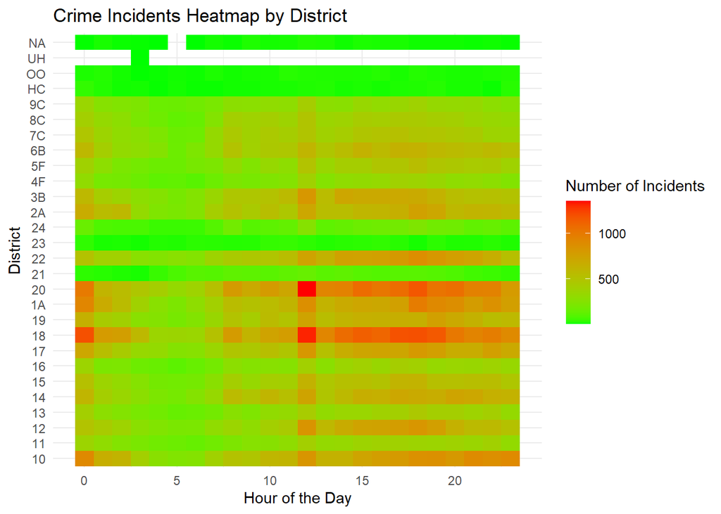

```r
# Create a heatmap
ggplot(incidents_by_district_hour, aes(x = RMSOccurrenceHour, y = District, fill = IncidentCount)) +
  geom_tile() +
  labs(title = "Crime Incidents Heatmap by District",
       x = "Hour of the Day",
       y = "District",
       fill = "Number of Incidents") +
  scale_fill_gradient(low = "green", high = "red") +  # You can adjust colors as needed
  theme_minimal()
```